Inicio ← Clase 3 - Parte 1 Descargar .Rmd Clase 3 - Parte 3 →

# Curso-Taller: Análisis Hidrológico de Cuencas con R

Clase 3: Modelación hidrológica conceptual con GR4J (parte 2)

Harold Llauca

# 📦 Preparación del entorno de trabajo

Se configura el entorno en R, definiendo el directorio de trabajo y cargando los paquetes necesarios para asegurar un flujo de trabajo ordenado y reproducible.

## 📦 Instalación y carga de paquetes

```r
# Establecer mirror de CRAN
options(repos = c(CRAN = "https://cloud.r-project.org"))

# Lista de paquetes necesarios
packages <- c(
  "openxlsx",  # lectura de archivos Excel (.xlsx)
  "zoo",       # manejo de series temporales
  "dplyr",     # manipulación de datos (data frames)
  "terra",     # manejo de datos geoespaciales (raster y vector)
  "airGR",     # implementación de modelos hidrológicos tipo GR (GR4J, GR5J, etc.)
  "rtop",      # modelación hidrológica regional (transferencia a cuencas no aforadas)
  "hydroGOF"   # métricas de evaluación de desempeño hidrológico (NSE, KGE, RMSE, etc.)
)

# Instalar paquetes si no están instalados
for (pkg in packages) {
  if (!requireNamespace(pkg, quietly = TRUE)) {
    install.packages(pkg)
  }
}

# Cargar paquetes
invisible(lapply(packages, function(pkg) {
  suppressPackageStartupMessages(library(pkg, character.only = TRUE))
}))
```

# ☁️ Cargar datos de entrada

En esta sección se cargan los datos de entrada previamente generados, los cuales contienen las series temporales de precipitación, evapotranspiración potencial y caudal observado. Estos datos serán utilizados para la implementación del modelo hidrológico GR4J.

```r
#-----------------------------------------------------------
# Cargar datos de entrada para el modelo GR4J
#-----------------------------------------------------------

# Leer archivo RDS con los datos de entrada
Inputs <- readRDS('./Modules/Clase_3/inputs/model_inputs_lumped.rds')

# Visualizar las primeras filas
head(Inputs)
```

```
##       DatesR         P        E          Q
## 1 1981-01-01 0.0000000 3.861269 0.11296420
## 2 1981-01-02 0.9299275 3.960805 0.13045006
## 3 1981-01-03 1.7251805 3.583615 0.12878474
## 4 1981-01-04 2.5148261 3.576449 0.12684187
## 5 1981-01-05 0.5296795 3.488778 0.13072761
## 6 1981-01-06 5.9252677 3.493946 0.09436813
```

```r
#-----------------------------------------------------------
# Cálculo del área de la cuenca
#-----------------------------------------------------------

# Cargar shapefile de la cuenca
cat <- vect('./Data/SIG/basin.shp')  # Sistema de referencia: WGS84

# Calcular el área de la cuenca en km2
area <- terra::expanse(cat, unit = 'km')

# Mostrar resultado
area
```

```
## [1] 3112.915
```

# ☁️ Configuración del modelo

Se define una función auxiliar para evaluar el desempeño del modelo GR4J. Esta función compara los caudales simulados y observados, calcula métricas hidrológicas de desempeño y, opcionalmente, genera un hidrograma comparativo entre ambas series. También permite excluir el periodo de calentamiento del modelo (warm-up) del cálculo de las métricas.

```r
#-----------------------------------------------------------
# Función auxiliar para evaluar resultados del modelo GR4J
#-----------------------------------------------------------

gr4j_metrics <- function(flow_sim,
                         flow_obs,
                         time_sim,
                         warmup_period = 0,
                         title = "Simulación con el modelo GR4J",
                         plot = TRUE) {

  # Verificar que las series tengan la misma longitud
  stopifnot(
    length(flow_sim) == length(flow_obs),
    length(flow_obs) == length(time_sim)
  )

  # Identificar datos posteriores al periodo de warm-up
  idwup <- seq_along(flow_sim) > warmup_period

  # Calcular métricas de desempeño hidrológico
  gof <- round(data.frame(
    KGE    = hydroGOF::KGE(flow_obs[idwup], flow_sim[idwup]),
    NSE    = hydroGOF::NSE(flow_obs[idwup], flow_sim[idwup]),
    logNSE = hydroGOF::NSE(
      flow_obs[idwup],
      flow_sim[idwup],
      fun = log,
      epsilon.type = "Pushpalatha2012"
    ),
    RMSE  = hydroGOF::rmse(flow_obs[idwup], flow_sim[idwup]),
    PBIAS = hydroGOF::pbias(flow_obs[idwup], flow_sim[idwup])
  ), 2)

  # Retornar solo métricas si no se desea graficar
  if (!plot) return(gof)

  # Configuración gráfica base
  par(
    mfrow = c(1, 1),
    mar = c(3, 3, 2, 1),
    mgp = c(1.5, 0.2, 0),
    cex = 0.7,
    cex.axis = 0.8,
    tck = -0.01
  )

  # Definir límites del eje Y
  ylim_vals <- c(0, 1.1 * max(flow_obs, flow_sim, na.rm = TRUE))

  # Graficar caudal observado
  plot(
    time_sim,
    flow_obs,
    col = "black",
    type = "p",
    lwd = 1,
    xlab = "Tiempo [días]",
    ylab = expression("Caudal medio diario [m"^3*"/s]"),
    main = title,
    ylim = ylim_vals
  )

  # Agregar caudal simulado
  lines(
    time_sim,
    flow_sim,
    col = "magenta",
    lwd = 1
  )

  # Mostrar límite del periodo de warm-up
  if (warmup_period > 0 && warmup_period < length(time_sim)) {
    abline(
      v = time_sim[warmup_period],
      col = "red",
      lty = 2,
      lwd = 1
    )

    mtext(
      "Calentamiento",
      side = 2,
      line = -2,
      adj = 0.75,
      col = "red",
      cex = 0.7,
    )
  }

  # Agregar leyenda
  legend(
    "topleft",
    legend = c("Observado", "Simulado"),
    col = c("black", "magenta"),
    pch = c(16, NA),
    lty = c(NA, 1),
    lwd = c(NA, 1),
    bty = "n"
  )

  # Agregar métricas en la parte superior del gráfico
  for (i in seq_along(gof)) {
    mtext(
      bquote(.(names(gof)[i]) == .(gof[[i]])),
      side = 3,
      line = -1 - i,
      adj = 0.98,
      cex = 0.7
    )
  }

  # Retornar métricas
  return(gof)
}
```

El modelo GR4J posee cuatro parámetros principales que controlan el almacenamiento, intercambio y transferencia del agua dentro de la cuenca. Antes de la calibración, se definen los rangos mínimos y máximos permitidos para cada parámetro.

```r
#-----------------------------------------------------------
# Definir rangos de parámetros del modelo GR4J
#-----------------------------------------------------------

# Nombres de los parámetros del modelo GR4J
par_names <- c("X1", "X2", "X3", "X4")

# Límites inferiores de los parámetros
lower <- c(1, -10, 1, 0.5)

# Límites superiores de los parámetros
upper <- c(1500, 5, 500, 4)

# Asignar nombres a los vectores de límites
names(lower) <- par_names
names(upper) <- par_names

# Mostrar límites inferiores y superiores
print(lower)
```

```
##    X1    X2    X3    X4
##   1.0 -10.0   1.0   0.5
```

```r
print(upper)
```

```
##   X1   X2   X3   X4
## 1500    5  500    4
```

Se definen los periodos de calibración y validación del modelo. El periodo de calibración se utiliza para estimar los parámetros óptimos, mientras que el periodo de validación permite evaluar la capacidad del modelo para reproducir caudales en un periodo independiente. Además, se considera un año inicial como periodo de calentamiento (warm-up) para reducir el efecto de las condiciones iniciales del modelo.

```r
#-----------------------------------------------------------
# Definir periodos de calibración, validación y warm-up
#-----------------------------------------------------------

# Periodo de calibración
ini_cal <- as.Date("1981-01-01")
end_cal <- as.Date("2004-12-31")

# Índices del periodo de calibración
idx <- which(as.Date(Inputs$DatesR) == ini_cal):
       which(as.Date(Inputs$DatesR) == end_cal)

# Periodo de warm-up dentro de la calibración
wup <- 1:365

# Periodo de validación
ini_val <- as.Date("2005-01-01")
end_val <- as.Date("2016-12-31")

# Índices del periodo de validación
idy <- which(as.Date(Inputs$DatesR) == ini_val):
       which(as.Date(Inputs$DatesR) == end_val)
```

Finalmente, se grafica el hidrograma observado y se indican los periodos utilizados para el calentamiento, calibración y validación del modelo. Esta figura permite verificar visualmente que los periodos han sido correctamente definidos.

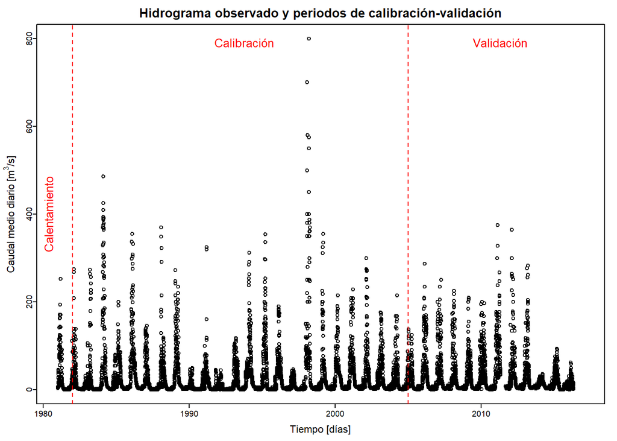

```r
#-----------------------------------------------------------
# Visualizar periodos de calibración y validación
#-----------------------------------------------------------

# Configuración gráfica
par(
  mfrow = c(1, 1),
  mar = c(3, 3, 2, 1),
  mgp = c(1.5, 0.2, 0),
  cex = 0.7,
  cex.axis = 0.8,
  tck = -0.01
)

# Graficar caudal observado convertido de mm/d a m3/s
plot(
  Inputs$DatesR,
  Inputs$Q * area / 86.4,
  col = "black",
  type = "p",
  cex = 0.8,
  lwd = 1,
  xlab = "Tiempo [días]",
  ylab = expression("Caudal medio diario [m"^3*"/s]"),
  main = "Hidrograma observado y periodos de calibración-validación"
)

# Línea que marca el final del warm-up
abline(
  v = as.POSIXct(ini_cal + length(wup)),
  col = "red",
  lty = 2,
  lwd = 1
)

# Línea que marca el inicio de la validación
abline(
  v = as.POSIXct(ini_val),
  col = "red",
  lty = 2,
  lwd = 1
)

# Etiquetas de los periodos
mtext(
  "Calentamiento",
  side = 2,
  line = -1.5,
  adj = 0.50,
  col = "red",
  cex=0.8
)

mtext(
  "Calibración",
  side = 3,
  line = -2,
  adj = 0.35,
  col = "red",
  cex=0.8
)

mtext(
  "Validación",
  side = 3,
  line = -2,
  adj = 0.85,
  col = "red",
  cex=0.8
)
```

# 🖥️ Calibración del modelo

En esta sección se presentan tres enfoques de calibración del modelo GR4J: una calibración manual y dos automáticas (método Michel y algoritmo SCE-UA). El objetivo es comparar sus resultados y comprender sus diferencias. Sin embargo, en aplicaciones reales no es estrictamente necesario utilizar los tres métodos; generalmente basta con una calibración automática bien configurada.

Se recomienda iniciar con una calibración manual, ya que permite comprender la sensibilidad del modelo frente a sus parámetros. Por ejemplo: X1 controla la capacidad del reservorio de producción (almacenamiento de agua en el suelo), X2 representa el intercambio de agua subterránea, X3 define la capacidad del reservorio de enrutamiento (controlando la atenuación del caudal), y X4 está relacionado con el tiempo base del hidrograma (respuesta de la cuenca).

Este entendimiento es clave para interpretar adecuadamente los resultados obtenidos durante la calibración automática.

## Calibración manual (exploración de parámetros óptimos)

En esta etapa se realiza una primera simulación del modelo GR4J mediante una selección manual de parámetros. Este ejercicio permite explorar la sensibilidad del modelo frente a diferentes combinaciones de parámetros y comprender cómo estos influyen en la respuesta hidrológica simulada

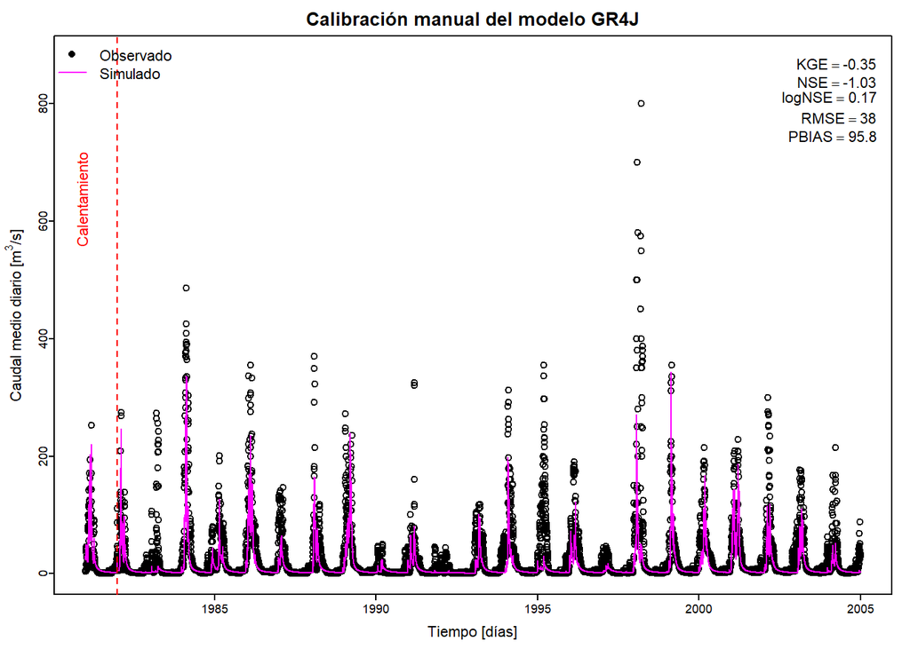

```r
#-----------------------------------------------------------
# Calibración manual del modelo GR4J
#-----------------------------------------------------------

# Definir parámetros iniciales del modelo GR4J
Best_param_1 <- c(
  X1 = 5,     # capacidad del reservorio de producción [mm]
  X2 = 1,     # coeficiente de intercambio subterráneo [mm/d]
  X3 = 100,   # capacidad del reservorio de enrutamiento [mm]
  X4 = 1      # tiempo base del hidrograma unitario [días]
)

# Crear objeto de entrada requerido por airGR
InputsModel <- airGR::CreateInputsModel(
  FUN_MOD = airGR::RunModel_GR4J,
  DatesR  = as.POSIXlt(Inputs$DatesR),
  Precip  = as.numeric(Inputs$P),
  PotEvap = as.numeric(Inputs$E)
)

# Configurar periodo de simulación
# idx extrae los datos del periodo de calibración
RunOptions <- airGR::CreateRunOptions(
  FUN_MOD       = airGR::RunModel_GR4J,
  InputsModel   = InputsModel,
  IndPeriod_Run = idx,
  warnings      = FALSE,
  verbose       = FALSE
)

# Ejecutar modelo GR4J
Outputs <- airGR::RunModel(
  Param       = Best_param_1,
  InputsModel = InputsModel,
  RunOptions  = RunOptions,
  FUN_MOD     = airGR::RunModel_GR4J
)

# Evaluar desempeño del modelo
# idx extrae los datos del periodo de calibración
gof1 <- gr4j_metrics(
  flow_sim      = Outputs$Qsim * area / 86.4,  # convertir mm/d a m3/s
  flow_obs      = Inputs$Q[idx] * area / 86.4, # convertir mm/d a m3/s
  time_sim      = Inputs$DatesR[idx],
  warmup_period = 365,
  title         = "Calibración manual del modelo GR4J",
  plot          = TRUE
)
```

## Calibración automática con airGR

En esta sección se realiza la calibración automática del modelo GR4J utilizando el algoritmo de Michel, implementado en el paquete airGR. Este método permite estimar los parámetros óptimos del modelo a partir de una función objetivo, en este caso el coeficiente de eficiencia de Kling-Gupta (KGE), buscando maximizar el ajuste entre caudales simulados y observados.

```r
#-----------------------------------------------------------
# Calibración automática del modelo GR4J (Método Michel)
#-----------------------------------------------------------

# parámetros iniciales (solo punto de partida del algoritmo);
# no son finales y deben estar dentro de los rangos min–max
parametros_ini <- c(
  X1 = 10,    # reservorio de producción [mm]
  X2 = 1,     # intercambio subterráneo [mm/d]
  X3 = 250,   # reservorio de enrutamiento [mm]
  X4 = 2      # tiempo base [días]
)

# Crear objeto de entrada para airGR
InputsModel <- airGR::CreateInputsModel(
  FUN_MOD = airGR::RunModel_GR4J,
  DatesR  = as.POSIXlt(Inputs$DatesR),
  Precip  = as.numeric(Inputs$P),
  PotEvap = as.numeric(Inputs$E)
)

# Configurar ejecución del modelo
RunOptions <- airGR::CreateRunOptions(
  FUN_MOD          = airGR::RunModel_GR4J,
  InputsModel      = InputsModel,
  IndPeriod_Run    = idx,
  IndPeriod_WarmUp = wup,
  warnings         = FALSE,
  verbose          = FALSE
)

# Definir función objetivo (KGE)
# idx extrae los datos del periodo de calibración
InputsCrit <- airGR::CreateInputsCrit(
  FUN_CRIT   = airGR::ErrorCrit_KGE,
  InputsModel = InputsModel,
  RunOptions  = RunOptions,
  Obs         = Inputs$Q[idx]
)

# Opciones de calibración (algoritmo de Michel)
Calib_Options <- airGR::CreateCalibOptions(
  FUN_MOD   = airGR::RunModel_GR4J,
  FUN_CALIB = airGR::Calibration_Michel
)

# Ejecutar calibración automática
OutputsCalib <- airGR::Calibration(
  InputsModel  = InputsModel,
  RunOptions   = RunOptions,
  InputsCrit   = InputsCrit,
  CalibOptions = Calib_Options,
  FUN_MOD      = airGR::RunModel_GR4J,
  FUN_CALIB    = airGR::Calibration_Michel,
  FUN_CRIT     = airGR::ErrorCrit_KGE
)
```

```
## Grid-Screening in progress (0% 20% 40% 60% 80% 100%)
##   Screening completed (81 runs)
##       Param =  169.017,   -0.020,   20.697,    1.417
##       Crit. KGE[Q]       = -0.2754
## Steepest-descent local search in progress
```

[output not shown]

[output cut: 51 more lines]

[output not shown]

```
##   Calibration completed (197 iterations, 1804 runs)
##       Param =    0.008,    1.731,   39.024,    2.256
##       Crit. KGE[Q]       = 0.7276
```

```r
# Extraer parámetros óptimos
Best_param_2 <- OutputsCalib$ParamFinalR
Best_param_2
```

```
## [1]  0.008496973  1.731323569 39.023838447  2.256110146
```

```r
# Ejecutar modelo con parámetros calibrados
Outputs <- airGR::RunModel(
  Param       = Best_param_2,
  InputsModel = InputsModel,
  RunOptions  = RunOptions,
  FUN_MOD     = airGR::RunModel_GR4J
)
```

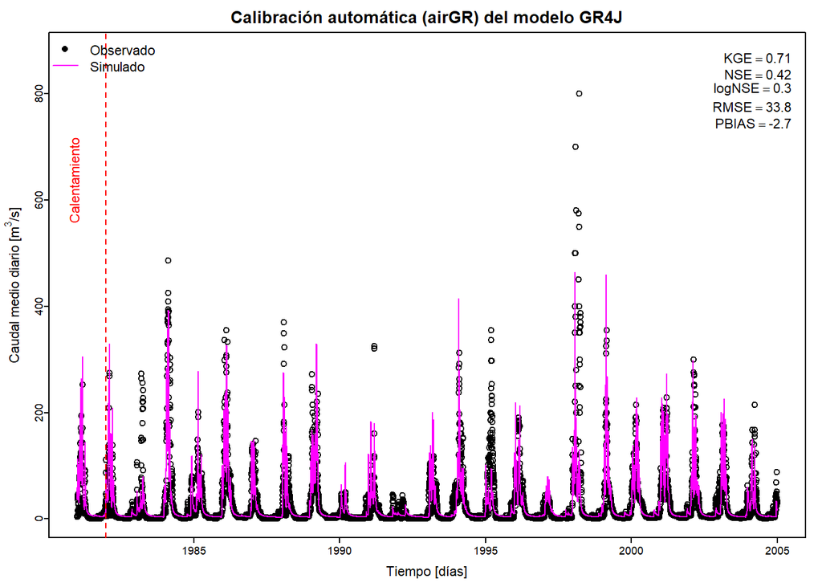

```r
# Evaluar desempeño del modelo
# idx extrae los datos del periodo de calibración
gof2 <- gr4j_metrics(
  flow_sim      = Outputs$Qsim * area / 86.4, # mm/d → m3/s
  flow_obs      = Inputs$Q[idx] * area / 86.4,
  time_sim      = Inputs$DatesR[idx],
  warmup_period = 365,
  title         = "Calibración automática (airGR) del modelo GR4J",
  plot          = TRUE
)
```

## Calibración automática del modelo GR4J con algoritmo SCE-UA

En esta sección se calibra el modelo GR4J mediante el algoritmo SCE-UA, una técnica de optimización global ampliamente utilizada en hidrología. A diferencia del método de calibración Michel implementado en airGR, en este enfoque se define explícitamente una función objetivo personalizada, que combina diferentes métricas de desempeño (como KGE, NSE y RMSE) mediante ponderaciones. Esto permite orientar la calibración hacia distintos aspectos del comportamiento hidrológico y obtener un conjunto de parámetros que reproduzca de manera más adecuada los caudales observados según los criterios definidos por el usuario.

```r
#-----------------------------------------------------------
# Calibración automática del modelo GR4J (algoritmo SCE-UA)
#-----------------------------------------------------------

# parámetros iniciales (solo punto de partida del algoritmo);
# no son finales y deben estar dentro de los rangos min–max
parametros_ini <- c(
  X1 = 10,    # reservorio de producción [mm]
  X2 = 1,     # intercambio subterráneo [mm/d]
  X3 = 250,   # reservorio de enrutamiento [mm]
  X4 = 2      # tiempo base [días]
)

# Crear objeto de entrada para airGR
InputsModel <- airGR::CreateInputsModel(
  FUN_MOD = airGR::RunModel_GR4J,
  DatesR  = as.POSIXlt(Inputs$DatesR),
  Precip  = as.numeric(Inputs$P),
  PotEvap = as.numeric(Inputs$E)
)

# Configurar ejecución del modelo
RunOptions <- airGR::CreateRunOptions(
  FUN_MOD          = airGR::RunModel_GR4J,
  InputsModel      = InputsModel,
  IndPeriod_Run    = idx,
  IndPeriod_WarmUp = wup,
  warnings         = FALSE,
  verbose          = FALSE
)

# Definir función objetivo para la calibración
OF <- function(param) {

  # Asignar nombres a los parámetros
  names(param) <- names(parametros_ini)

  # Ejecutar modelo GR4J
  Outputs <- airGR::RunModel(
    Param       = param,
    InputsModel = InputsModel,
    RunOptions  = RunOptions,
    FUN_MOD     = airGR::RunModel_GR4J
  )

  # Extraer caudales simulados y observados sin periodo de warm-up
  # idx extrae los datos del periodo de calibración
  qsim <- Outputs$Qsim[-wup]
  qobs <- Inputs$Q[idx][-wup]

# Calcular función objetivo
# En este bloque se muestran distintas alternativas de función objetivo.
# La idea es que SCE-UA minimice el valor de "fo".
# Por ejemplo, si se usa 1 - KGE, el algoritmo buscará maximizar el KGE.

# fo <- 1 - hydroGOF::KGE(qobs, qsim)
# usar KGE como función objetivo principal

# fo <- 1 - hydroGOF::NSE(qobs, qsim)
# usar NSE como función objetivo principal

# fo <- hydroGOF::rmse(qobs, qsim)
# usar RMSE como función objetivo principal

# fo <- 0.6 * (1 - hydroGOF::KGE(qobs, qsim)) +
#       0.4 * (1 - hydroGOF::NSE(qobs, qsim))
# combinar KGE y NSE, dando mayor peso al KGE

# fo <- 0.6 * (1 - hydroGOF::KGE(qobs, qsim)) +
#       0.3 * (1 - hydroGOF::NSE(qobs, qsim)) +
#       0.1 * hydroGOF::rmse(qobs, qsim)
# combinar KGE, NSE y RMSE con pesos definidos por el usuario

fo <- 0.6 * (1 - hydroGOF::KGE(qobs, qsim)) +
      0.3 * (1 - hydroGOF::NSE(qobs, qsim)) +
      0.1 * hydroGOF::rmse(qobs, qsim)
  return(fo)
}

# Ejecutar calibración con SCE-UA
calib <- rtop::sceua(
  OFUN   = OF,                              # función objetivo a minimizar
  pars   = as.numeric(parametros_ini),      # valores iniciales de los parámetros
  lower  = as.numeric(lower),               # límites inferiores de los parámetros
  upper  = as.numeric(upper),               # límites superiores de los parámetros
  maxn   = 1000,                            # número máximo de evaluaciones (iteraciones)
                                            # (recomendado mayor, e.g., 20000 para estudios finales)
  kstop  = 10,                              # criterio de convergencia (número de iteraciones sin mejora significativa)
  pcento = 0.1,                             # porcentaje de mejora mínima para continuar la optimización
  ngs    = 8,                               # número de complejos (subpoblaciones)
  npg    = 2 * length(parametros_ini) + 1,  # tamaño de cada complejo
  nps    = length(parametros_ini) + 1,      # número de puntos en cada sub-complejo
  nspl   = 2 * length(parametros_ini) + 1,  # número de pasos de evolución por complejo
  mings  = 4                                # número mínimo de complejos activos
)
```

```
## 154 best 1.55 function convergence 20 parameter convergence 9344.56
## 233 best 0.621 function convergence 20 parameter convergence 8944.025
## 314 best 0.552 function convergence 20 parameter convergence 8812.717
## 384 best 0.551 function convergence 20 parameter convergence 8794.835
## 441 best 0.505 function convergence 20 parameter convergence 8697.791
## 490 best 0.466 function convergence 20 parameter convergence 8708.976
## 548 best 0.45 function convergence 20 parameter convergence 8645.602
## 604 best 0.449 function convergence 20 parameter convergence 8626.782
## 656 best 0.447 function convergence 20 parameter convergence 8626.782
## 707 best 0.442 function convergence 20 parameter convergence 8626.782
## 756 best 0.44 function convergence 11.1 parameter convergence 8626.75
## 807 best 0.44 function convergence 3.41 parameter convergence 8626.75
## 861 best 0.439 function convergence 2.28 parameter convergence 8626.764
## 917 best 0.439 function convergence 2.27 parameter convergence 8626.775
## 975 best 0.439 function convergence 1.4 parameter convergence 8626.787
## 1036 best 0.439 function convergence 0.589 parameter convergence 8626.787
```

```r
# Extraer parámetros calibrados
Best_param_3 <- calib$par
names(Best_param_3) <- names(parametros_ini)
Best_param_3
```

```
##        X1        X2        X3        X4
##  1.002985  2.344201 44.034612  2.200355
```

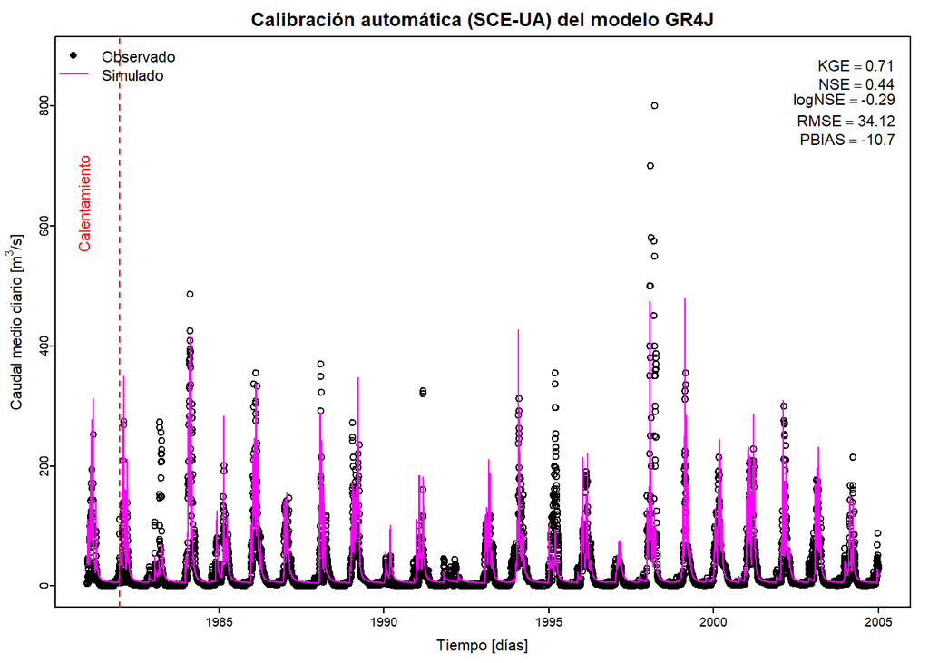

```r
# Ejecutar modelo GR4J con parámetros calibrados
Outputs <- airGR::RunModel(
  Param       = Best_param_3,
  InputsModel = InputsModel,
  RunOptions  = RunOptions,
  FUN_MOD     = airGR::RunModel_GR4J
)

# Evaluar desempeño del modelo
gof3 <- gr4j_metrics(
  flow_sim      = Outputs$Qsim * area / 86.4,  # mm/d → m3/s
  flow_obs      = Inputs$Q[idx] * area / 86.4,
  time_sim      = Inputs$DatesR[idx],
  warmup_period = 365,
  title         = "Calibración automática (SCE-UA) del modelo GR4J",
  plot          = TRUE
)
```

# Validación del modelo

En esta sección se evalúa el desempeño del modelo GR4J utilizando un periodo independiente al de calibración. Este proceso, conocido como validación, permite verificar la capacidad del modelo para reproducir el comportamiento hidrológico bajo condiciones no utilizadas durante el ajuste de parámetros.

Se utilizan los parámetros obtenidos en la calibración previa y se ejecuta el modelo sobre el periodo de validación definido.

```r
#-----------------------------------------------------------
# Seleccionar parámetros calibrados de mejor desempeño
#-----------------------------------------------------------
Best_param <- Best_param_3  # proveniente de SCE-UA
```

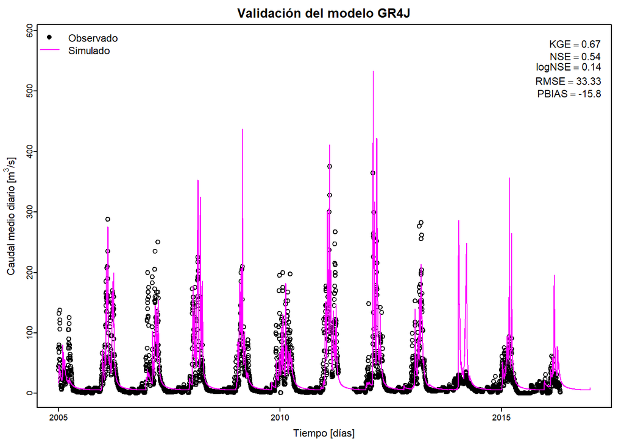

```r
#-----------------------------------------------------------
# Validación del modelo GR4J
#-----------------------------------------------------------

# Crear objeto de entrada para airGR
InputsModel <- airGR::CreateInputsModel(
  FUN_MOD = airGR::RunModel_GR4J,
  DatesR  = as.POSIXlt(Inputs$DatesR),
  Precip  = as.numeric(Inputs$P),
  PotEvap = as.numeric(Inputs$E)
)

# Configurar ejecución del modelo en periodo de validación
# idy extrae los datos del periodo de validación
RunOptions <- airGR::CreateRunOptions(
  FUN_MOD       = airGR::RunModel_GR4J,
  InputsModel   = InputsModel,
  IndPeriod_Run = idy,        # periodo de validación
  warnings      = FALSE,
  verbose       = FALSE
)

# Ejecutar modelo GR4J con parámetros calibrados
Outputs <- airGR::RunModel(
  Param       = Best_param,
  InputsModel = InputsModel,
  RunOptions  = RunOptions,
  FUN_MOD     = airGR::RunModel_GR4J
)

# Evaluar desempeño del modelo en validación
# idy extrae los datos del periodo de validación
gof_val <- gr4j_metrics(
  flow_sim = Outputs$Qsim * area / 86.4,      # mm/d → m3/s
  flow_obs = Inputs$Q[idy] * area / 86.4,
  time_sim = Inputs$DatesR[idy],
  title    = "Validación del modelo GR4J",
  plot     = TRUE
)
```

# Exportar resultados

Finalmente, se guardan los resultados del modelo GR4J, ejecutado para el periodo completo de análisis.

```r
# Configuracion de los datos de entrada
InputsModel <- airGR::CreateInputsModel(FUN_MOD=RunModel_GR4J,
                                        DatesR=as.POSIXlt(Inputs$DatesR),
                                        Precip=as.numeric(Inputs$P),
                                        PotEvap=as.numeric(Inputs$E))

# Configuracion de la corrida del modelo
RunOptions <- airGR::CreateRunOptions(FUN_MOD=RunModel_GR4J,
                               InputsModel=InputsModel,
                               IndPeriod_Run=seq_along(Inputs$DatesR), #1981-2016
                               warnings=FALSE,
                               verbose=FALSE)

# Ejecutar el modelo
Outputs    <- airGR::RunModel(Param=Best_param,
                       InputsModel=InputsModel,
                       RunOptions=RunOptions,
                       FUN_MOD=RunModel_GR4J)
```

```r
# Exportar resultados del modelo calibrado
Outputs$Qobs   <- Inputs$Q
Outputs$IdCal  <- idx
Outputs$IdVal  <- idy
Outputs$WarmUp <- wup
Outputs$Param  <- Best_param
Outputs$Area   <- area

saveRDS(Outputs, "./Modules/Clase_3/outputs/model_outputs_lumped.rds")
```

📌 Clase 3 · Parte 2 → Clase 3 · Parte 3